# 02 - Data Visualization

## 2.4 Chi tiêu Marketing có tương quan với Thu nhập không?

Chúng ta phân tích mối tương quan giữa `Marketing_Spend` (Chi tiêu quảng cáo) và `Earnings_USD` (Thu nhập) bằng biểu đồ **Bubble Plot (Biểu đồ bong bóng)**. Kích thước của bóng đại diện cho `Job_Completed` (Số job hoàn thành) và màu sắc đại diện cho `Project_Type` (Loại dự án).

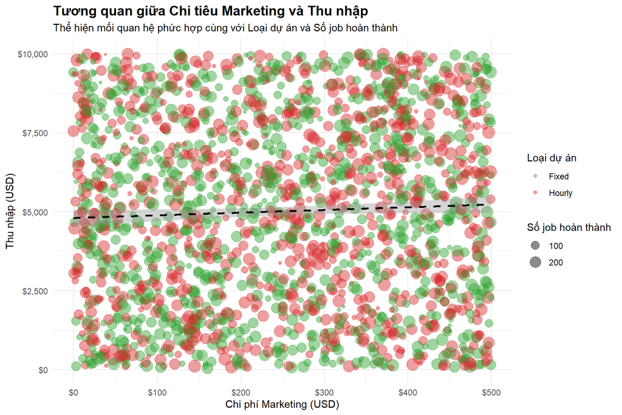

```r
ggplot(freelancer, aes(x = Marketing_Spend, y = Earnings_USD)) +
  geom_point(aes(size = Job_Completed, color = Project_Type), alpha = 0.45) +
  geom_smooth(method = "lm", formula = y ~ x, color = "black", linetype = "dashed", se = TRUE) +
  scale_y_continuous(labels = dollar) +
  scale_x_continuous(labels = dollar) +
  scale_color_manual(values = c("Fixed" = "#2ca02c", "Hourly" = "#d62728"), name = "Loại dự án") +
  scale_size_continuous(name = "Số job hoàn thành") +
  labs(title = "Tương quan giữa Chi tiêu Marketing và Thu nhập",
       subtitle = "Thể hiện mối quan hệ phức hợp cùng với Loại dự án và Số job hoàn thành",
       x = "Chi phí Marketing (USD)", y = "Thu nhập (USD)") +
  theme_minimal() +
  theme(plot.title = element_text(face = "bold", size = 14),
        legend.position = "right")
```

## 2.5 Ảnh hưởng của Loại dự án (Project_Type: Fixed vs Hourly) đến thu nhập

Để so sánh chi tiết hình dạng phân phối thu nhập giữa hai nhóm loại dự án Cố định (Fixed) và Theo giờ (Hourly), chúng ta sử dụng biểu đồ **mật độ chồng lấp (Overlapping Density Plot)**.

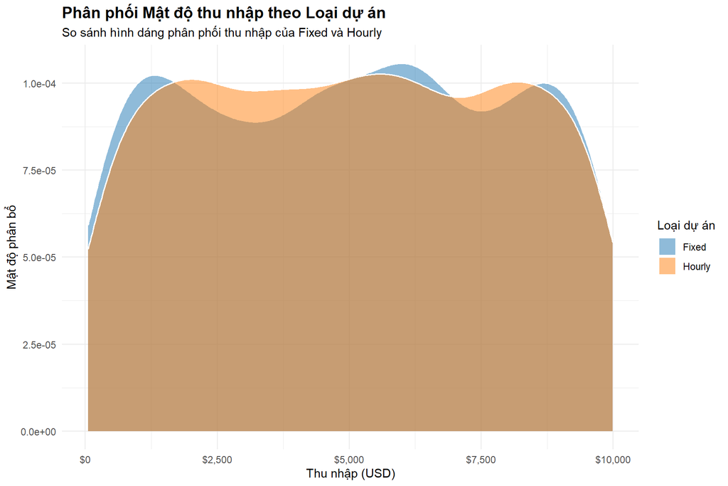

```r
ggplot(freelancer, aes(x = Earnings_USD, fill = Project_Type)) +
  geom_density(alpha = 0.5, color = "white", size = 0.6) +
  scale_x_continuous(labels = dollar) +
  scale_fill_manual(values = c("Fixed" = "#1f77b4", "Hourly" = "#ff7f0e"), name = "Loại dự án") +
  labs(title = "Phân phối Mật độ thu nhập theo Loại dự án",
       subtitle = "So sánh hình dáng phân phối thu nhập của Fixed và Hourly",
       x = "Thu nhập (USD)", y = "Mật độ phân bổ") +
  theme_minimal() +
  theme(plot.title = element_text(face = "bold", size = 14))
```

> **Nhận định chi tiết:**
> - **Quan sát trực quan:** Phân phối thu nhập của cả hai hình thức dự án (Fixed và Hourly) gần như trùng khớp hoàn toàn lên nhau. Mức độ biến thiên trải dài đặn từ 0 tới khoảng 10,000 USD và không có các đỉnh (peaks) vút lên rõ rệt ở bất kỳ khoảng thu nhập nào.
> - **Phân tích ý nghĩa:** Đồ thị dàn đều chứng tỏ thu nhập phân bố rất đồng đều (uniform distribution) bất kể là làm dự án theo giờ hay cố định. Điều này khẳng định loại hình dự án (Project Type) không phải là yếu tố tiên quyết tạo nên sự khác biệt về tổng thu nhập trên thị trường.
> - **Hàm ý thực tiễn:** Freelancer không nên quá kén chọn giữa dự án theo giờ (Hourly) hay dự án cố định (Fixed). Cơ hội đạt được mức thu nhập cao ($10,000) tồn tại song song ở cả hai hình thức. Phát hiện này cũng là cơ sở quan trọng để Thành viên 3 tiếp tục kiểm định sâu hơn trong mô hình Hồi quy.